# R_para_primers

Blanca, Trinidad, Julie

2024-11-17

## R para primers

El diseño de primers con herramientas computacionales no es novedad, incluso hay paquetes en R que pueden ayudarte a esta tarea como openPrimeR de Bioconductor. Este proyecto hace uso del programa Biostrings, ciclos, funciones y condiciones para encontrar primers en secuencias de no más de 20,000 nucleótidos, sólo de DNA, sólo para eucariotas.

Este programa permite el diseño de primers *forward* (Fw) y *reverse* (rv)

## Pre-evaluación de la secuencia

Función `pre_fw` realiza un asesoramiento inicial de la secuencia codificante mediante el uso de la instrucción `if()` para verificar los siguientes requerimientos:

- La clase del objeto que contiene la secuencia, debe ser DNAStringSet.
- No es degenerado
- Longitud de la secuencia < 20,000 nucleótidos
- Contiene el codón de inicio ATG (para metionina)

## Creación de la función para evaluar la secuencia

```r
library(Biostrings)
secun_prueba1 <- readDNAStringSet("Uso_del_proyecto_files/gallus.fasta") # 1. Cargar secuencia

pre_fw <- function(secun_prueba) {
  tipo_sec <- class(secun_prueba)
  tipo_sec[1]

  # Para evaluar tipo de secuencia
  if (tipo_sec[1] == "DNAStringSet") {

     # Comprobar que no es degenerado
    no_degenerado <- alphabetFrequency(secun_prueba, baseOnly=TRUE)
    if (no_degenerado[5] == 0) {

      # Verificar el largo de la secuencia
      longt <- width(secun_prueba)
      if ( longt < 20000) {

        # Codon de inicio: TAC -> ATG
        codon_in <- vmatchPattern ("ATG", secun_prueba)
        codon_in[[1]][1]
        print(codon_in)
      } else {
        print("La capacidad maxima es de 20,000 nucleotidos")}}
  } else {
      print("Cambiar a DNA")
    }
  }

pre_fw(secun_prueba1)
```

```
## MIndex object of length 1
## $`NM_205281.2 Gallus gallus lysozyme (renal amyloidosis) (LYZ), mRNA`
## IRanges object with 7 ranges and 0 metadata columns:
##           start       end     width
##       <integer> <integer> <integer>
##   [1]        32        34         3
##   [2]       100       102         3
##   [3]       119       121         3
##   [4]       228       230         3
##   [5]       282       284         3
##   [6]       387       389         3
##   [7]       398       400         3
```

```r
# El codon de inicio: si está muy cerca, porque está más de una vez, intenete con otras posiciones
```

#### Función *fw_primer**

`fw_primer` evalúa primers *forward* potenciales tomando en cuenta 3 parámetros:

- Posición del codón de inicio
- Secuencia a evaluar
- Longitud de la secuencia a evaluar

```r
primer_fw <-function (inicio_codon, secun_prueba, ultima) {
  detener <- inicio_codon - ultima
  inicio <- 0
  while (inicio <= detener & ultima < inicio_codon ) {
          inicio <- inicio + 1
          primer_fd <- subseq (secun_prueba, start=inicio, end=ultima)
          ultima <- ultima + 1

          final<-complement(primer_fd)
          ##### Eveluar condiciones de primer
          # Patrones

          tripletes <- trinucleotideFrequency(final)
          patrones_malos <- tripletes[c(22, 43, 44, 16, 41, 49, 61)]
          no_hay <- c(0,0,0,0,0,0,0)
          comparacion <- all(patrones_malos == no_hay)

          if (comparacion == TRUE) { #Seguir evaluando el primer

            # Poct de CG: 50-60 %
            longt <- width(final)
            cont_cg <- letterFrequency(final, "CG")
            porc_cg <- (cont_cg / longt) * 100

            if (porc_cg < 61 & porc_cg > 49) {#Seguir evaluando
              #Temperatura: 55 - 65 °C
              cont_cg <- letterFrequency(final, "CG")
              cont_at <- letterFrequency(final, "AT")
              temperatura <- (4*cont_cg) + (2*cont_at)

              if (temperatura >54 & temperatura <66 ) {

                print("Forward")
                print(final)
                print(paste("Porcentaje de CG: ", porc_cg))
                print(paste("Tm: ", temperatura,"°C"))

              }
              }
          }
          }
  }
```

El resultado es el primer, la secuencia complementaria, que es evaluado mediante instrucciones `if()` a fin de que cumpla los diferentes criterios:

*Evaluación*

*Ejemplo de aplicacón de la función*

```r
primer_fw (32, secun_prueba1, 18) # Colocar el valor del start , secuencia, long del primer.
```

```
## [1] "Forward"
## DNAStringSet object of length 1:
##     width seq                                               names
## [1]    18 GCGACACACATGCTGTGA                                NM_205281.2 Gallu...
## [1] "Porcentaje de CG:  55.5555555555556"
## [1] "Tm:  56 °C"
## [1] "Forward"
## DNAStringSet object of length 1:
##     width seq                                               names
## [1]    18 CGACACACATGCTGTGAC                                NM_205281.2 Gallu...
## [1] "Porcentaje de CG:  55.5555555555556"
## [1] "Tm:  56 °C"
## [1] "Forward"
## DNAStringSet object of length 1:
##     width seq                                               names
## [1]    18 GACACACATGCTGTGACC                                NM_205281.2 Gallu...
## [1] "Porcentaje de CG:  55.5555555555556"
## [1] "Tm:  56 °C"
## [1] "Forward"
## DNAStringSet object of length 1:
##     width seq                                               names
## [1]    18 ACACACATGCTGTGACCG                                NM_205281.2 Gallu...
## [1] "Porcentaje de CG:  55.5555555555556"
## [1] "Tm:  56 °C"
## [1] "Forward"
## DNAStringSet object of length 1:
##     width seq                                               names
## [1]    18 CACACATGCTGTGACCGT                                NM_205281.2 Gallu...
## [1] "Porcentaje de CG:  55.5555555555556"
## [1] "Tm:  56 °C"
## [1] "Forward"
## DNAStringSet object of length 1:
##     width seq                                               names
## [1]    18 CACATGCTGTGACCGTTG                                NM_205281.2 Gallu...
## [1] "Porcentaje de CG:  55.5555555555556"
## [1] "Tm:  56 °C"
```

Implementación completa en: evaluar.R.

#### TGA - **primer_rev_ct1**

TGA primer_rev_ct1

```r
#####Primer con TGA

revertida <-reverse(secun_prueba1)
revertida
```

```
## DNAStringSet object of length 1:
##     width seq                                               names
## [1]   588 CCGCAAACGCATATCAGCAAAAT...ACAGCATGTGTGTCGCCCTGACG NM_205281.2 Gallu...
```

```r
vmatchPattern ("AGT",revertida) -> tga
tga
```

```
## MIndex object of length 1
## $`NM_205281.2 Gallus gallus lysozyme (renal amyloidosis) (LYZ), mRNA`
## IRanges object with 8 ranges and 0 metadata columns:
##           start       end     width
##       <integer> <integer> <integer>
##   [1]       114       116         3
##   [2]       188       190         3
##   [3]       227       229         3
##   [4]       251       253         3
##   [5]       451       453         3
##   [6]       467       469         3
##   [7]       484       486         3
##   [8]       554       556         3
```

```r
primer_rev_ct1<-function(tga1,secrev,ultima) {
  tga_rv_primers <- list ()
  detener <- tga1 - ultima

  inicio <- 0
  while (inicio <= detener & ultima < tga1 ) {
    inicio <- inicio + 1
    primer_rv<- subseq(revertida, start=inicio, end=ultima)
    ultima <- ultima + 1
    final<-complement(primer_rv) #la secuencia complentaria

    tripletes <- trinucleotideFrequency(final)#patrones que favorecen horquillas,
    #dímeros..
    patrones_malos <- tripletes[c(22, 43, 44, 16, 41, 49, 61)]
    no_hay <- c(0,0,0,0,0,0,0)
    comparacion <- all(patrones_malos == no_hay)

    if (comparacion == TRUE) {
      longt <- width(primer_rv)#revisar %gc
      cont_cg <- letterFrequency(primer_rv, "CG")
      porc_cg <- (cont_cg / longt) * 100

      if (porc_cg < 61 & porc_cg > 49){
        cont_cg <- letterFrequency(primer_rv, "CG")
        cont_at <- letterFrequency(primer_rv, "AT")
        temperatura <- (4*cont_cg) + (2*cont_at) ##Tm

        if (temperatura >54 & temperatura <66 ) {
          tga_rv_primers <- append (tga_rv_primers, list (list (primer = primer_rv, porc_cg = porc_cg, temperatura = temperatura)))
        }
      }
    }
  }
  if (length(tga_rv_primers) > 0) {
    for (primer in tga_rv_primers) {
      print("reverse tga")
      print(primer$primer)
      print(paste("Porcentaje de CG: ", primer$porc_cg))
      print(paste("Tm: ", primer$temperatura, "°C"))
    }
  } else {
    tga_rv_primers <- NULL
  }
  return (tga_rv_primers)
}

primer_rev_ct1(114,revertida, 20) # Primers con TGA, puedes, jugar con los valores de
```

```
## [1] "reverse tga"
## DNAStringSet object of length 1:
##     width seq                                               names
## [1]    20 CCGCAAACGCATATCAGCAA                              NM_205281.2 Gallu...
## [1] "Porcentaje de CG:  50"
## [1] "Tm:  60 °C"
```

```
## [[1]]
## [[1]]$primer
## DNAStringSet object of length 1:
##     width seq                                               names
## [1]    20 CCGCAAACGCATATCAGCAA                              NM_205281.2 Gallu...
##
## [[1]]$porc_cg
##      C|G
## [1,]  50
##
## [[1]]$temperatura
##      C|G
## [1,]  60
```

```r
# Start del objeto TGA, considerando tu región codificante (CDS)
```

#### TAG - **primer_rev_ct2**

TAG primer_rev_ct2

```r
#####Primer con TAG

vmatchPattern ("GAT",revertida)->tag
tag
```

```
## MIndex object of length 1
## $`NM_205281.2 Gallus gallus lysozyme (renal amyloidosis) (LYZ), mRNA`
## IRanges object with 0 ranges and 0 metadata columns:
##        start       end     width
##    <integer> <integer> <integer>
```

```r
primer_rev_ct2<-function(tag1,secrev,ultima) {
  tag_rv_primers <- list ()
  detener <- tag1 - ultima
  inicio <- 0
  while (inicio <= detener & ultima < tag1 ) {
    inicio <- inicio + 1
    primer_rv<- subseq(revertida, start=inicio, end=ultima)
    ultima <- ultima + 1
    final<-complement(primer_rv)##secuencia complementaria

    tripletes <- trinucleotideFrequency(primer_rv)#revisar patrones indeseados
    patrones_malos <- tripletes [c(22, 43, 44, 16, 41, 49, 61)]
    no_hay <- c(0,0,0,0,0,0,0)
    comparacion <- all(patrones_malos == no_hay)

    if (comparacion == TRUE) {

      longt <- width(primer_rv)#%gc
      cont_cg <- letterFrequency(primer_rv, "CG")
      porc_cg <- (cont_cg / longt) * 100

      if (porc_cg < 61 & porc_cg > 49) {##%gc
        cont_cg <- letterFrequency(primer_rv, "CG")
        cont_at <- letterFrequency(primer_rv, "AT")
        temperatura <- (4*cont_cg) + (2*cont_at) ##Tm

        if (temperatura >54 & temperatura <66 ) {
          tag_rv_primers <- append (tag_rv_primers, list(list (primer = primer_rv, porc_cg = porc_cg, temperatura = temperatura)))
        }
      }
    }
  }
  if (length(tag_rv_primers) > 0) {
    for (primer in tag_rv_primers) {
      print("reverse tag")
      print(primer$primer)
      print(paste("Porcentaje de CG: ", primer$porc_cg))
      print(paste("Tm: ", primer$temperatura, "°C"))
    }
  } else {
    tag_rv_primers <- NULL
  }
  return (tag_rv_primers)
}


primer_rev_ct2(222,revertida, 20)#reverse TAG,sujeto a que tenga este patrón,puedes
```

```
## [1] "reverse tag"
## DNAStringSet object of length 1:
##     width seq                                               names
## [1]    20 CCGCAAACGCATATCAGCAA                              NM_205281.2 Gallu...
## [1] "Porcentaje de CG:  50"
## [1] "Tm:  60 °C"
## [1] "reverse tag"
## DNAStringSet object of length 1:
##     width seq                                               names
## [1]    20 GTGCGCAAGTACGGCAAAGG                              NM_205281.2 Gallu...
## [1] "Porcentaje de CG:  60"
## [1] "Tm:  64 °C"
## [1] "reverse tag"
## DNAStringSet object of length 1:
##     width seq                                               names
## [1]    20 GTAGCGACTGCTAGAAGAAG                              NM_205281.2 Gallu...
## [1] "Porcentaje de CG:  50"
## [1] "Tm:  60 °C"
## [1] "reverse tag"
## DNAStringSet object of length 1:
##     width seq                                               names
## [1]    20 TAGCGACTGCTAGAAGAAGC                              NM_205281.2 Gallu...
## [1] "Porcentaje de CG:  50"
## [1] "Tm:  60 °C"
## [1] "reverse tag"
## DNAStringSet object of length 1:
##     width seq                                               names
## [1]    20 AGCGACTGCTAGAAGAAGCG                              NM_205281.2 Gallu...
## [1] "Porcentaje de CG:  55"
## [1] "Tm:  62 °C"
```

```
## [[1]]
## [[1]]$primer
## DNAStringSet object of length 1:
##     width seq                                               names
## [1]    20 CCGCAAACGCATATCAGCAA                              NM_205281.2 Gallu...
##
## [[1]]$porc_cg
##      C|G
## [1,]  50
##
## [[1]]$temperatura
##      C|G
## [1,]  60
##
##
## [[2]]
## [[2]]$primer
## DNAStringSet object of length 1:
##     width seq                                               names
## [1]    20 GTGCGCAAGTACGGCAAAGG                              NM_205281.2 Gallu...
##
## [[2]]$porc_cg
##      C|G
## [1,]  60
##
## [[2]]$temperatura
##      C|G
## [1,]  64
##
##
## [[3]]
## [[3]]$primer
## DNAStringSet object of length 1:
##     width seq                                               names
## [1]    20 GTAGCGACTGCTAGAAGAAG                              NM_205281.2 Gallu...
##
## [[3]]$porc_cg
##      C|G
## [1,]  50
##
```

[output cut: 18 more lines]

```
##
##
## [[5]]
## [[5]]$primer
## DNAStringSet object of length 1:
##     width seq                                               names
## [1]    20 AGCGACTGCTAGAAGAAGCG                              NM_205281.2 Gallu...
##
## [[5]]$porc_cg
##      C|G
## [1,]  55
##
## [[5]]$temperatura
##      C|G
## [1,]  62
```

```r
#jugar con los valores de start del objeto tga, considerando tu región codificante (CDS)
```

#### TAA - **primer_rev_ct3**

TAA primer_rev_ct3

```r
######Primers con TAA
vmatchPattern("AAT",revertida)->taa
taa
```

```
## MIndex object of length 1
## $`NM_205281.2 Gallus gallus lysozyme (renal amyloidosis) (LYZ), mRNA`
## IRanges object with 7 ranges and 0 metadata columns:
##           start       end     width
##       <integer> <integer> <integer>
##   [1]        21        23         3
##   [2]        37        39         3
##   [3]       239       241         3
##   [4]       367       369         3
##   [5]       394       396         3
##   [6]       448       450         3
##   [7]       542       544         3
```

```r
primer_rev_ct3<-function(taa1,secrev,ultima) {
  taa_rv_primers <- list ()
  detener <- taa1 - ultima
  inicio <- 0
  while (inicio <= detener & ultima < taa1 ) {
    inicio <- inicio + 1
    primer_rv<- subseq(revertida, start=inicio, end=ultima)
    ultima <- ultima + 1
    tripletes <- trinucleotideFrequency(primer_rv)#revisar patrones indeseados
    patrones_malos <- tripletes[c(22, 43, 44, 16, 41, 49, 61)]
    no_hay <- c(0,0,0,0,0,0,0)
    comparacion <- all(patrones_malos == no_hay)

    if (comparacion == TRUE) { #Seguir evaluando el primer
      # Poct de CG
      longt <- width(primer_rv)
      cont_cg <- letterFrequency(primer_rv, "CG")
      porc_cg <- (cont_cg / longt) * 100

      if (porc_cg < 61 & porc_cg > 49) {##%gc
        cont_cg <- letterFrequency(primer_rv, "CG")
        cont_at <- letterFrequency(primer_rv, "AT")
        temperatura <- (4*cont_cg) + (2*cont_at) ##Tm

        if (temperatura >54 & temperatura <66 ) {
          taa_rv_primers <- append (taa_rv_primers, list(list (primer = primer_rv, porc_cg = porc_cg, temperatura = temperatura)))
        }
      }
    }
  }
  if (length(taa_rv_primers) > 0) {
    for (primer in taa_rv_primers) {
      print("reverse taa")
      print(primer$primer)
      print(paste("Porcentaje de CG: ", primer$porc_cg))
      print(paste("Tm: ", primer$temperatura, "°C"))
    }
  } else {
    taa_rv_primers <- NULL
  }
  return (taa_rv_primers)
}

primer_rev_ct3(37,revertida, 20) #reverse TAG,sujeto a que tenga este patrón,puedes
```

```
## [1] "reverse taa"
## DNAStringSet object of length 1:
##     width seq                                               names
## [1]    20 CCGCAAACGCATATCAGCAA                              NM_205281.2 Gallu...
## [1] "Porcentaje de CG:  50"
## [1] "Tm:  60 °C"
```

```
## [[1]]
## [[1]]$primer
## DNAStringSet object of length 1:
##     width seq                                               names
## [1]    20 CCGCAAACGCATATCAGCAA                              NM_205281.2 Gallu...
##
## [[1]]$porc_cg
##      C|G
## [1,]  50
##
## [[1]]$temperatura
##      C|G
## [1,]  60
```

```r
#jugar con los valores de start del objeto tga, considerando tu región codificante (CDS)
```

## Archivo FASTA

- Requiere que los primers sean guardados en una lista
- Uso de 2 funciones:
  1. Adición de secuencias de primer a una lista
  2. Conversión de la lista de primers válidos a FASTA
- Uso del paquete seqinr para uso de `write.fasta`

```r
#Objetos con las funciones
primer_fw (32, secun_prueba1,18) -> fw_primers
```

```
## [1] "Forward"
## DNAStringSet object of length 1:
##     width seq                                               names
## [1]    18 GCGACACACATGCTGTGA                                NM_205281.2 Gallu...
## [1] "Porcentaje de CG:  55.5555555555556"
## [1] "Tm:  56 °C"
## [1] "Forward"
## DNAStringSet object of length 1:
##     width seq                                               names
## [1]    18 CGACACACATGCTGTGAC                                NM_205281.2 Gallu...
## [1] "Porcentaje de CG:  55.5555555555556"
## [1] "Tm:  56 °C"
## [1] "Forward"
## DNAStringSet object of length 1:
##     width seq                                               names
## [1]    18 GACACACATGCTGTGACC                                NM_205281.2 Gallu...
## [1] "Porcentaje de CG:  55.5555555555556"
## [1] "Tm:  56 °C"
## [1] "Forward"
## DNAStringSet object of length 1:
##     width seq                                               names
## [1]    18 ACACACATGCTGTGACCG                                NM_205281.2 Gallu...
## [1] "Porcentaje de CG:  55.5555555555556"
## [1] "Tm:  56 °C"
## [1] "Forward"
## DNAStringSet object of length 1:
##     width seq                                               names
## [1]    18 CACACATGCTGTGACCGT                                NM_205281.2 Gallu...
## [1] "Porcentaje de CG:  55.5555555555556"
## [1] "Tm:  56 °C"
## [1] "Forward"
## DNAStringSet object of length 1:
##     width seq                                               names
## [1]    18 CACATGCTGTGACCGTTG                                NM_205281.2 Gallu...
## [1] "Porcentaje de CG:  55.5555555555556"
## [1] "Tm:  56 °C"
```

```r
primer_rev_ct1 (114, revertida,20) -> tga_primers
```

```
## [1] "reverse tga"
## DNAStringSet object of length 1:
##     width seq                                               names
## [1]    20 CCGCAAACGCATATCAGCAA                              NM_205281.2 Gallu...
## [1] "Porcentaje de CG:  50"
## [1] "Tm:  60 °C"
```

```r
primer_rev_ct2 (222, revertida,20) -> tag_primers
```

```
## [1] "reverse tag"
## DNAStringSet object of length 1:
##     width seq                                               names
## [1]    20 CCGCAAACGCATATCAGCAA                              NM_205281.2 Gallu...
## [1] "Porcentaje de CG:  50"
## [1] "Tm:  60 °C"
## [1] "reverse tag"
## DNAStringSet object of length 1:
##     width seq                                               names
## [1]    20 GTGCGCAAGTACGGCAAAGG                              NM_205281.2 Gallu...
## [1] "Porcentaje de CG:  60"
## [1] "Tm:  64 °C"
## [1] "reverse tag"
## DNAStringSet object of length 1:
##     width seq                                               names
## [1]    20 GTAGCGACTGCTAGAAGAAG                              NM_205281.2 Gallu...
## [1] "Porcentaje de CG:  50"
## [1] "Tm:  60 °C"
## [1] "reverse tag"
## DNAStringSet object of length 1:
##     width seq                                               names
## [1]    20 TAGCGACTGCTAGAAGAAGC                              NM_205281.2 Gallu...
## [1] "Porcentaje de CG:  50"
## [1] "Tm:  60 °C"
## [1] "reverse tag"
## DNAStringSet object of length 1:
##     width seq                                               names
## [1]    20 AGCGACTGCTAGAAGAAGCG                              NM_205281.2 Gallu...
## [1] "Porcentaje de CG:  55"
## [1] "Tm:  62 °C"
```

```r
primer_rev_ct3 (37, revertida,20) -> taa_primers
```

```
## [1] "reverse taa"
## DNAStringSet object of length 1:
##     width seq                                               names
## [1]    20 CCGCAAACGCATATCAGCAA                              NM_205281.2 Gallu...
## [1] "Porcentaje de CG:  50"
## [1] "Tm:  60 °C"
```

#### 1) Función `primers_validos`

Adición de primers válidos, que no den como resultado una `list ()` o un `NULL`

```r
primers_validos <- function (fw_primers, tga_primers, tag_primers, taa_primers) {
  lista_primers <- list()
  #forward
  if (!is.null(fw_primers)) {
    for (primer in fw_primers) {
      lista_primers <- c(lista_primers, list(list(nombre = "Forward primer", secuencias = primer$primer)))
    }
  }
  #TGA reverso
  if (!is.null(tga_primers)) {
    for (primer in tga_primers) {
      lista_primers <- c(lista_primers, list(list(nombre = "TGA - Reverse primer", secuencias = primer$primer)))
    }
  }
  #TAG reverso
  if (!is.null(tag_primers)) {
    for (primer in tag_primers) {
      lista_primers <- c(lista_primers, list(list(nombre = "TAG - Reverse primer", secuencias = primer$primer)))
    }
  }
  #TAA reverso
  if (!is.null(taa_primers)) {
    for (primer in taa_primers) {
      lista_primers <- c(lista_primers, list(list(nombre = "TAA - Reverse primer", secuencias = primer$primer)))
    }
  }
  return(lista_primers)
}

#Guardar en un objeto
lista_primers <- primers_validos (fw_primers, tga_primers, tag_primers, taa_primers)
```

#### 2) Función `escribir.fasta`

Escribir la lista a un archivo FASTA

```r
escribir_fasta <- function (lista_primers) {
  lista_secuencias <- list ()
  lista_nombres <- list ()

  for (primer in lista_primers) {
    secuencias <- as.character (primer$secuencias) #sino se imprime todo el DNAStringSet en el fasta
    lista_secuencias <- c(lista_secuencias, secuencias)
    lista_nombres <- c(lista_nombres, primer$nombre)
  }

  if (length(lista_secuencias) > 0  & length(lista_nombres) > 0) {
    library(seqinr)
    write.fasta (sequences = lista_secuencias,
                names = lista_nombres,
                nbchar = 80,
                file.out = "Uso_del_proyecto_files/primer_gallus.fasta")
    print("Ver primers en carpeta de resultados")
  }
}

escribir_fasta (lista_primers)
```

```
## [1] "Ver primers en carpeta de resultados"
```

####Puntos a considerar al usar esta secuencia/limitaciones con ejemplos

##Ideal

Secuencia en la que el codón de inicio aparece una sola vez y los codones de paro no se extienden hasta la región codificante

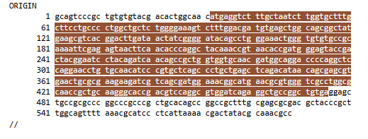

##Regiones no codificantes del gen cortas.

Cunado hay regiones no codificantes cortas en uno o ambos extremos, es muy probable que no salga alguno de los primers. El usuario debe decidir cuanto está dispuesto a ceder para obtenerlos.

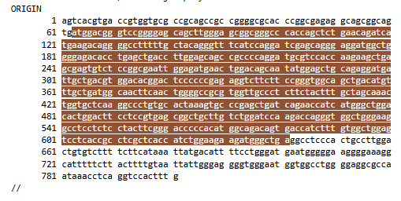

Bax, mus musculus

```r
# Lectura de la secuencia
secun_prueba1 <- readDNAStringSet("Uso_del_proyecto_files/musmusculusBAX.fasta")
secun_prueba1
```

```
## DNAStringSet object of length 1:
##     width seq                                               names
## [1]   801 AGTCACGTGACCGTGGTGCGCCG...CAATAAACCTCAGGTCCACTTTG NM_007527.4 Mus m...
```

```r
############################
####################     PRIMERS FORWARD      ############################
############################

#   IDENTIFICACION DE LA SEC CODIF (CDS)

pre_fw <- function(secun_prueba) {
  tipo_sec <- class(secun_prueba)
  tipo_sec[1]

  # Para evaluar tipo de secuencia
  if (tipo_sec[1] == "DNAStringSet") {
    # Comprobar que no es degenerado
    no_degenerado <- alphabetFrequency(secun_prueba, baseOnly=TRUE)

    if (no_degenerado[5] == 0) {
      # Verificar el largo de la secuencia
      longt <- width(secun_prueba)
      if ( longt < 20000) {
        # Codon de inicio: TAC -> ATG
        codon_in <- vmatchPattern("ATG", secun_prueba)
        codon_in[[1]][1]
      } else { print("La capacidad maxima es de 20,000 nucleotidos")}}} else { print("Cambiar a DNA")}
}

pre_fw(secun_prueba1) # Prueba
```

```
## IRanges object with 1 range and 0 metadata columns:
##           start       end     width
##       <integer> <integer> <integer>
##   [1]        63        65         3
```

```r
####################

#  GENERADOR DE PRIMERS FORWARD

primer_fw <-function(inicio_codon, secun_prueba, ultima) {
  detener <- inicio_codon - ultima
  inicio <- 0
  while (inicio <= detener & ultima < inicio_codon ) {
    inicio <- inicio + 1
    primer_fd <- subseq(secun_prueba, start=inicio, end=ultima)
    ultima <- ultima + 1

    final<-complement(primer_fd)
    ##### Eveluar condiciones de primer
    # Patrones
    tripletes <- trinucleotideFrequency(final)
    patrones_malos <- tripletes[c(22, 43, 44, 16, 41, 49, 61)]
    no_hay <- c(0,0,0,0,0,0,0)
    comparacion <- all(patrones_malos == no_hay)
    tolerancia<-sum(patrones_malos!=0)
    if (comparacion == TRUE |tolerancia==1) { #Seguir evaluando el primer
      # Poct de CG: 50-60 %
      longt <- width(final)
      cont_cg <- letterFrequency(final, "CG")
      porc_cg <- (cont_cg / longt) * 100

      if (porc_cg < 61 & porc_cg > 49) {#Seguir evaluando
        #Temperatura: 55 - 65 °C
        cont_cg <- letterFrequency(final, "CG")
        cont_at <- letterFrequency(final, "AT")
        temperatura <- (4*cont_cg) + (2*cont_at)

        if (temperatura >54 & temperatura <66 ) {

          print("Forward")
          print(final)
          print(paste("Porcentaje de CG: ", porc_cg))
          print(paste("Tm: ", temperatura))

        }
      }
    }
  }
}


primer_fw(63, secun_prueba1, 21) # Colocar el valor del start , secuencia, long del primer.
#Hasta 150 encuentra 2, pero se pasa por más de la mitad del límite
```

[output not shown]

[output not shown]

[output not shown]

[output not shown]

[output not shown]

##Cuando es muy corto el lado no codificante es muy corto

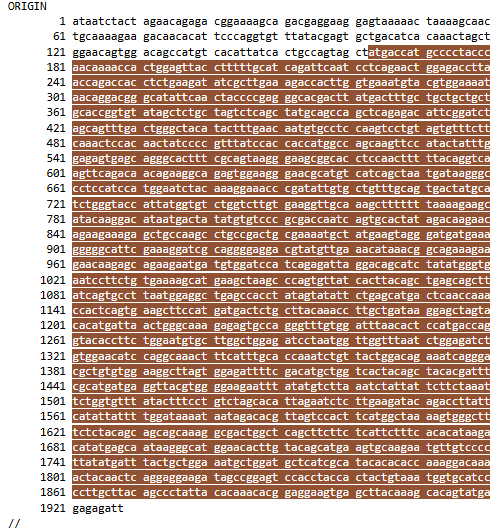

ESR, Xenopus laevis

```
## DNAStringSet object of length 1:
##     width seq                                               names
## [1]  1928 ATAATCTACTAGAACAGAGACGG...CAAAGCACAGTATGAGAGAGATT NM_001089617.1 Xe...
```

```
## DNAStringSet object of length 1:
##     width seq                                               names
## [1]  1928 TTAGAGAGAGTATGACACGAAAC...GGCAGAGACAAGATCATCTAATA NM_001089617.1 Xe...
```

```
## MIndex object of length 1
## $`NM_001089617.1 Xenopus laevis estrogen receptor 1 L homeolog (esr1.L), mRNA`
## IRanges object with 39 ranges and 0 metadata columns:
##            start       end     width
##        <integer> <integer> <integer>
##    [1]         9        11         3
##    [2]        29        31         3
##    [3]       181       183         3
##    [4]       209       211         3
##    [5]       242       244         3
##    ...       ...       ...       ...
##   [35]      1645      1647         3
##   [36]      1660      1662         3
##   [37]      1673      1675         3
##   [38]      1763      1765         3
##   [39]      1824      1826         3
```

```
## MIndex object of length 1
## $`NM_001089617.1 Xenopus laevis estrogen receptor 1 L homeolog (esr1.L), mRNA`
## IRanges object with 18 ranges and 0 metadata columns:
##            start       end     width
##        <integer> <integer> <integer>
##    [1]       106       108         3
##    [2]       335       337         3
##    [3]       344       346         3
##    [4]       395       397         3
##    [5]       403       405         3
##    ...       ...       ...       ...
##   [14]      1546      1548         3
##   [15]      1555      1557         3
##   [16]      1769      1771         3
##   [17]      1811      1813         3
##   [18]      1917      1919         3
```

```
## [1] "reverse tag"
## DNAStringSet object of length 1:
##     width seq                                               names
## [1]    20 ATGTCATCACCATCCACCTG                              NM_001089617.1 Xe...
## [1] "Porcentaje de CG:  50"
## [1] "Tm:  60"
## [1] "reverse tag"
## DNAStringSet object of length 1:
##     width seq                                               names
## [1]    20 TGTCATCACCATCCACCTGA                              NM_001089617.1 Xe...
## [1] "Porcentaje de CG:  50"
## [1] "Tm:  60"
## [1] "reverse tag"
## DNAStringSet object of length 1:
##     width seq                                               names
## [1]    20 GTCATCACCATCCACCTGAG                              NM_001089617.1 Xe...
## [1] "Porcentaje de CG:  55"
## [1] "Tm:  62"
## [1] "reverse tag"
## DNAStringSet object of length 1:
##     width seq                                               names
## [1]    20 TCATCACCATCCACCTGAGG                              NM_001089617.1 Xe...
## [1] "Porcentaje de CG:  55"
## [1] "Tm:  62"
## [1] "reverse tag"
## DNAStringSet object of length 1:
##     width seq                                               names
## [1]    20 CATCACCATCCACCTGAGGC                              NM_001089617.1 Xe...
## [1] "Porcentaje de CG:  60"
## [1] "Tm:  64"
## [1] "reverse tag"
## DNAStringSet object of length 1:
##     width seq                                               names
## [1]    20 ATCACCATCCACCTGAGGCC                              NM_001089617.1 Xe...
## [1] "Porcentaje de CG:  60"
## [1] "Tm:  64"
```

```
## MIndex object of length 1
## $`NM_001089617.1 Xenopus laevis estrogen receptor 1 L homeolog (esr1.L), mRNA`
## IRanges object with 26 ranges and 0 metadata columns:
##            start       end     width
##        <integer> <integer> <integer>
##    [1]        80        82         3
##    [2]       235       237         3
##    [3]       251       253         3
##    [4]       319       321         3
##    [5]       347       349         3
##    ...       ...       ...       ...
##   [22]      1627      1629         3
##   [23]      1688      1690         3
##   [24]      1876      1878         3
##   [25]      1883      1885         3
##   [26]      1925      1927         3
```

##Cuanto encuentra un condón de inicio o paro de manera precipitada

```r
secun_prueba1 <- readDNAStringSet("Uso_del_proyecto_files/cabraaopae.fasta")
secun_prueba1
```

```
## DNAStringSet object of length 1:
##     width seq                                               names
## [1]  1459 TGGCCTGTTCCAGCCCCTTCCAT...AAGATTCATCACGCTTCATGGCA XM_018062561.1 PR...
```

```r
#   IDENTIFICACION DE LA SEC CODIF (CDS)

pre_fw <- function(secun_prueba) {
  tipo_sec <- class(secun_prueba)
  tipo_sec[1]

  # Para evaluar tipo de secuencia
  if (tipo_sec[1] == "DNAStringSet") {
    # Comprobar que no es degenerado
    no_degenerado <- alphabetFrequency(secun_prueba, baseOnly=TRUE)

    if (no_degenerado[5] == 0) {
      # Verificar el largo de la secuencia
      longt <- width(secun_prueba)
      if ( longt < 20000) {
        # Codon de inicio: TAC -> ATG
        codon_in <- vmatchPattern("ATG", secun_prueba)
        codon_in[[1]][1]
      } else { print("La capacidad maxima es de 20,000 nucleotidos")}}} else { print("Cambiar a DNA")}
}

pre_fw(secun_prueba1) #Identifica un atg bastante lejos del inicio de la región codificante
```

```
## IRanges object with 1 range and 0 metadata columns:
##           start       end     width
##       <integer> <integer> <integer>
##   [1]        22        24         3
```

```r
####################

#  GENERADOR DE PRIMERS FORWARD

primer_fw <-function(inicio_codon, secun_prueba, ultima) {
  detener <- inicio_codon - ultima
  inicio <- 0
  while (inicio <= detener & ultima < inicio_codon ) {
    inicio <- inicio + 1
    primer_fd <- subseq(secun_prueba, start=inicio, end=ultima)
    ultima <- ultima + 1

    final<-complement(primer_fd)
    ##### Eveluar condiciones de primer
    # Patrones
    tripletes <- trinucleotideFrequency(final)
    patrones_malos <- tripletes[c(22, 43, 44, 16, 41, 49, 61)]
    no_hay <- c(0,0,0,0,0,0,0)
    comparacion <- all(patrones_malos == no_hay)
    tolerancia<-sum(patrones_malos!=0)
    if (comparacion == TRUE |tolerancia==1) { #Seguir evaluando el primer
      # Poct de CG: 50-60 %
      longt <- width(final)
      cont_cg <- letterFrequency(final, "CG")
      porc_cg <- (cont_cg / longt) * 100

      if (porc_cg < 61 & porc_cg > 49) {#Seguir evaluando
        #Temperatura: 55 - 65 °C
        cont_cg <- letterFrequency(final, "CG")
        cont_at <- letterFrequency(final, "AT")
        temperatura <- (4*cont_cg) + (2*cont_at)

        if (temperatura >54 & temperatura <66 ) {

          print("Forward")
          print(final)
          print(paste("Porcentaje de CG: ", porc_cg))
          print(paste("Tm: ", temperatura))

        }
      }
    }
  }
}


primer_fw(100, secun_prueba1,19) # Colocar el valor del start , secuencia, long del primer.
```

```
## [1] "Forward"
## DNAStringSet object of length 1:
##     width seq                                               names
## [1]    19 CTCCTTCGGCGGACTCAAT                               XM_018062561.1 PR...
## [1] "Porcentaje de CG:  57.8947368421053"
## [1] "Tm:  60"
## [1] "Forward"
## DNAStringSet object of length 1:
##     width seq                                               names
## [1]    19 TCCTTCGGCGGACTCAATG                               XM_018062561.1 PR...
## [1] "Porcentaje de CG:  57.8947368421053"
## [1] "Tm:  60"
## [1] "Forward"
## DNAStringSet object of length 1:
##     width seq                                               names
## [1]    19 CCTTCGGCGGACTCAATGA                               XM_018062561.1 PR...
## [1] "Porcentaje de CG:  57.8947368421053"
## [1] "Tm:  60"
## [1] "Forward"
## DNAStringSet object of length 1:
##     width seq                                               names
## [1]    19 CTTCGGCGGACTCAATGAC                               XM_018062561.1 PR...
## [1] "Porcentaje de CG:  57.8947368421053"
## [1] "Tm:  60"
## [1] "Forward"
## DNAStringSet object of length 1:
##     width seq                                               names
## [1]    19 TTCGGCGGACTCAATGACC                               XM_018062561.1 PR...
## [1] "Porcentaje de CG:  57.8947368421053"
## [1] "Tm:  60"
```

```r
#Hasta 150 encuentra 2, pero se pasa por más de la mitad del límite
```